# Flongle Experiment 3 (F3) - 16-04-2021

## Background

Two samples of two different haplotypes (FBM05 - used in F2, and LcDv70; 3 bp difference), one amplicon (Dv1F3, 725 bp), using the EXP-NBD104 Native Bacroding kit and LSK109 Ligation Sequencing kit.

- MN24471
- FA-03502
- FLow-cell: AGG667 (pore QC: 30 available pores)

Run for 16 hours (starting: 27 pores).

**Barcodes used:**

- BC01: CACAAAGACACCGACAACTTTCTT
- BC02: ACAGACGACTACAAACGGAATCGA

**Calculations for pooling barcodes:**

For the ligation library prep: 70fmol in 30ul of pooled (barcoded) amplicon DNA is needed.

Using this equation I calculated the total ng needed for 70fmol

ugDNA = pmol DNA x 660pg/pmol x 1ug/10^6pg x 700bp

- 1pmol = 1000fmol
- 1ug = 1000ng

After barcoding each sample was nanodropped:

- FBM05 = 11.1ng/ul in 15ul
- LcDv70 = 9.8ng/ul in 15ul  
  For approximately 30.2ng total - to be equimolar I added 15.1ng from each sample
- FBM05 = 1.4ul
- LcDv70 = 1.5ul

To make the final 30ul added 27.1ul water.

## Summary of run

A total of 42,465 reads with a qscore of >= 7 (pass).

A total of 7,304 reads with a qscore < 7 (fail).  
**Table 1. Summary stats of run**

| General summary: |  |
| --- | --- |
| Mean read length: | 849.4 |
| Mean read quality: | 11.2 |
| Median read length: | 869.0 |
| Median read quality: | 11.1 |
| Number of reads: | 42,465.0 |
| Read length N50: | 873.0 |
| STDEV read length: | 214.6 |
| Total bases: | 36,068,495.0 |

Note: mean read length and N50 are higher than Flongle run F2 because of the barcode length added to each sequence.

**Table 2. Number, percentage and megabases of reads above quality cutoffs.**

| Quality | # Reads | Mb |
| --- | --- | --- |
| >Q5: | 42465 (100.0%) | 36.1Mb |
| >Q7: | 42465 (100.0%) | 36.1Mb |
| >Q10: | 27869 (65.6%) | 23.9Mb |
| >Q12: | 15624 (36.8%) | 13.5Mb |
| >Q15: | 2560 (6.0%) | 2.2Mb |

## Demultiplexing and trimming adapters of pass reads using Porechop

```r
porechop -i ./F3_HAC_pass_all.fastq --discard_middle -o ./Intermediate_files/F3_porechop_hacpass_all.fastq
```

- `--discard-middle` removes any reads with an adapter found in the middle
- default adapter threshold for porechop is 90% identity for both start and end adapters
- default barcode threshold for porechop is 85% identity
- 40,192 / 42,465 reads had adapters trimmed from their start (2,651,382 bp removed)
- 34,679 / 42,465 reads had adapters trimmed from their end (1,716,735 bp removed)
- 40 / 42,465 reads were discarded based on middle adapters

### Trimmed reads then demultiplexed and saved to barcode-specific files:

**Table 3. Number of reads assigned to each barcode identified by porechop**

| Barcode | Reads | Bases |
| --- | --- | --- |
| BC01 | 10,609 | 8,162,479 |
| BC02 | 28,104 | 20,618,355 |
| BC12 | 1 | 334 |
| none | 3,661 | 2,865,803 |

BC12 was identified for the reverse of one read at 87% identity. (BC12: TCCGATTCTGCTTCTTTCTACCTG)

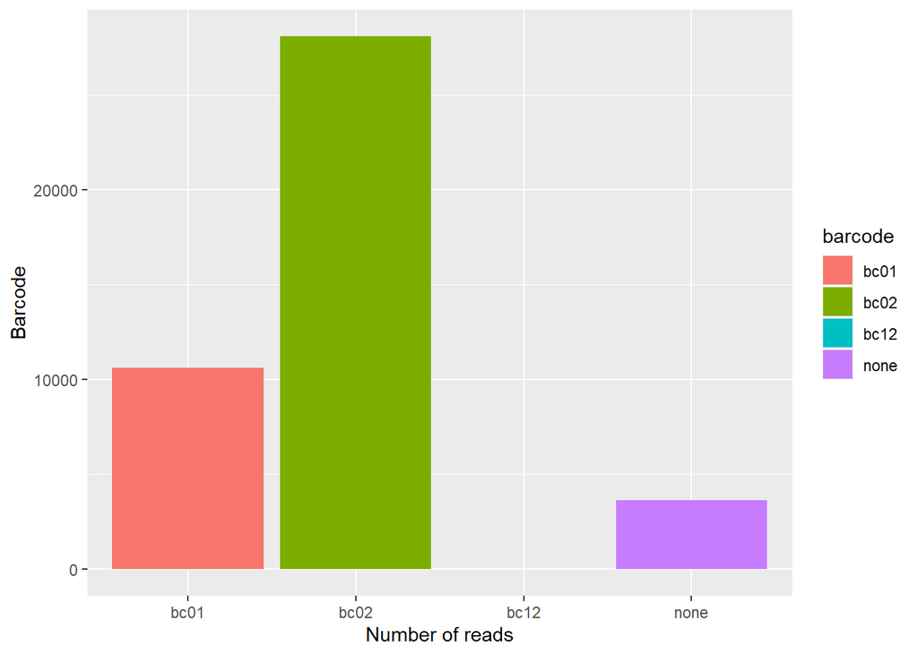

**Figure 1. Number of pass reads per barcode**

**Table 4A. General Summary stats after trimming**

| General summary: |  |
| --- | --- |
| **BC01** |  |
| Mean read length: | 769.4 |
| Mean read quality: | 11.9 |
| Median read length: | 752.0 |
| Median read quality: | 11.8 |
| Number of reads: | 10,609.0 |
| Read length N50: | 756.0 |
| STDEV read length: | 249.9 |
| Total bases: | 8,162,479.0 |
| **BC02** |  |
| Mean read length: | 733.6 |
| Mean read quality: | 11.8 |
| Median read length: | 751.0 |
| Median read quality: | 11.6 |
| Number of reads: | 28,104.0 |
| Read length N50: | 753.0 |
| STDEV read length: | 182.1 |
| Total bases: | 20,618,355.0 |
| **None** |  |
| Mean read length: | 782.8 |
| Mean read quality: | 10.4 |
| Median read length: | 761.0 |
| Median read quality: | 9.7 |
| Number of reads: | 3,661.0 |
| Read length N50: | 778.0 |
| STDEV read length: | 269.8 |
| Total bases: | 2,865,803.0 |

**Table 4B. Number, percentage and megabases of reads above quality cutoffs**

| Quality | # Reads | Mb |
| --- | --- | --- |
| **BC01** |  |  |
| >Q5: | 10609 (100.0%) | 8.2Mb |
| >Q7: | 10606 (100.0%) | 8.2Mb |
| >Q10: | 7758 (73.1%) | 5.9Mb |
| >Q12: | 4950 (46.7%) | 3.7Mb |
| >Q15: | 1353 (12.8%) | 1.0Mb |
| **BC02** |  |  |
| >Q5: | 28104 (100.0%) | 20.6Mb |
| >Q7: | 28092 (100.0%) | 20.6Mb |
| >Q10: | 19971 (71.1%) | 14.7Mb |
| >Q12: | 12660 (45.0%) | 9.3Mb |
| >Q15: | 3337 (11.9%) | 2,4Mb |
| **None** |  |  |
| >Q5: | 3661 (100.0%) | 2.9Mb |
| >Q7: | 3661 (100.0%) | 2.9Mb |
| >Q10: | 1714 (46.8%) | 1.3Mb |
| >Q12: | 941 (25.7%) | 0.7Mb |
| >Q15: | 239 (6.5%) | 0.2Mb |

### BC01 and BC02 only

Since there is no way to tell what sample “none” and BC12 came from I only continued with the two that were demultiplexed correctly.

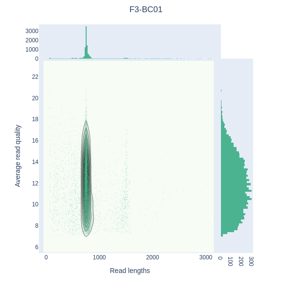

**Figure 2A. Length vs Quality KDE of BC01 reads**

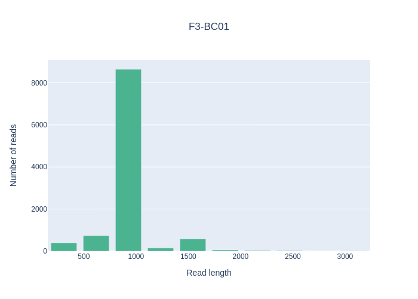

**Figure 2B. Histogram of read lengths of BC01 reads**

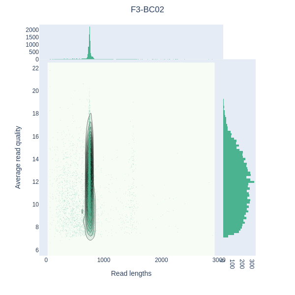

**Figure 3A. Length vs Quality KDE of BC02 reads**

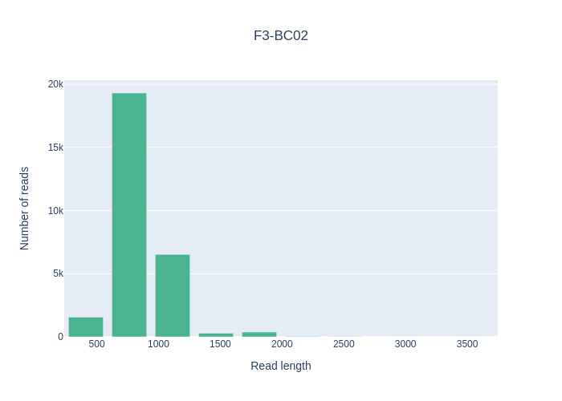

**Figure 3B. Histogram of read lengths of BC02 reads**

## Filtering pass reads (only BC01 and BC02) using NanoFilt - Note this is stricter length filtering than F2.

```r
 NanoFilt BC01.fastq -q 9 -l 600 --maxlength 770 --headcrop 20 --tailcrop 22 > F3_trimmed_bc01.fastq
 NanoFilt BC02.fastq -q 9 -l 600 --maxlength 770 --headcrop 20 --tailcrop 22 > F3_trimmed_bc01.fastq
```

[output not shown]

**Table 5B. Number, percentage and megabases of reads above quality cutoffs**

| Quality | # Reads | Mb |
| --- | --- | --- |
| BC01 |  |  |
| >Q5: | 10609 (100.0%) | 8.2Mb |
| >Q7: | 10606 (100.0%) | 8.2Mb |
| >Q10: | 7758 (73.1%) | 5.9Mb |
| >Q12: | 4950 (46.7%) | 3.7Mb |
| >Q15: | 1353 (12.8%) | 1.0Mb |
| BC02 |  |  |
| >Q5: 28104 | (100.0%) | 20.6Mb |
| >Q7: 28092 | (100.0%) | 20.6Mb |
| >Q10: 19971 | (71.1%) | 14.7Mb |
| >Q12: 12660 | (45.0%) | 9.3Mb |
| >Q15: 3337 | (11.9%) | 2.4Mb |

```r
minimap2 -ax map-ont -t 12  ../../../F2_20200319/FBM05_Dv1F3.fas F3_trimmed_bc01.fastq --sam-hit-only > F3_trimmed_bc01.sam
minimap2 -ax map-ont -t 12  ../../../F2_20200319/FBM05_Dv1F3.fas F3_trimmed_bc02.fastq --sam-hit-only > F3_trimmed_bc02.sam
```

- `-ax map-ont` generates CIGAR string and output alignments in the SAM format (`-a`) and uses the preset (`-x`) for *ONT reads (-k 15 for minimizer k-mer length)*
- `-t 12` 12 threads (only used for mapping not indexing)
- `--sam-hit-only` - output only mapped reads to SAM file
- number of minimizers: 114 (99.18% singletons
- number of reads mapped:
  1. BC01: 6213/6217
  2. BC02: 17698/17710

**Table 6. Mapping summary stats for each of the barcoded read sets. Error rate is estimated as the number of mismatches/number of bases mapped**

| Barcode | No.of reads | Mean read length | Mean read quality | Read N50 | Error rate | Mismatches | Bases mapped |
| --- | --- | --- | --- | --- | --- | --- | --- |
| BC01 | 6213 | 703.9 | 13.2 | 708.0 | 8.503164e-02 | 326909 | 4373579 |
| BC02 | 17698 | 704.8 | 12.8 | 708.0 | 9.026012e-02 | 989006 | 12474373 |

## Alignment of consensus sequences from demultiplexed samples.

This plot was automatically generated from my original Rmarkdown summary file - I know you can’t actually see the number of differences in it, but keeping it in for now and will try to zoom in to parts at a later date.

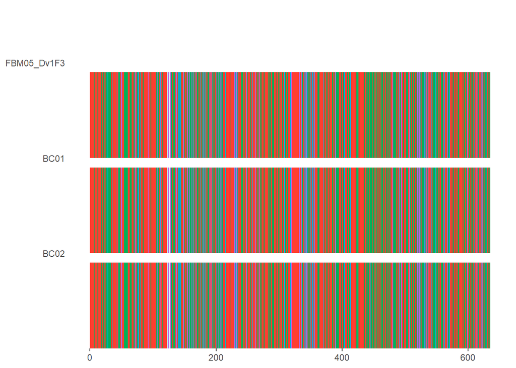

**Figure 11. Alignment of consensus sequences (BC01_consensus, BC02_consensus) to reference (FBM05_Dv1F3)**

| sampleID | VS | perc.ident |
| --- | --- | --- |
| FBM05_Dv1F3 | 0 | 100.00000 |
| BC01 | 0 | 100.00000 |
| BC02 | 3 | 99.52756 |

## Full length sequences only - update 2021-04-21

Recap: Two samples (France FBM05, and Loch Creran LcDv70) barcoded (BC01 and BC02 respectively)

This time keeping only full length sequences (`NanoFilt`) mapped to: 1. The FBM05 Sanger reference 2. The LcDv70 Sanger reference 3. To both Sanger references

To keep only full length:

```
 NanoFilt BC01.fastq -q 9 -l 767 --maxlength 767 > F3_full_length_bc01.fastq
      #72
 NanoFilt BC02.fastq -q 9 -l 767 --maxlength 767 > F3_full_length_bc02.fastq
      #232
```

767bp is the length of the total amplicon including primer binding sites.

Trim primer binding sites:

```
  NanoFilt F3_full_length_bc01.fastq --headcrop 20 --tailcrop 22 > F3_full_length_trimmed_bc01.fastq
  NanoFilt F3_full_length_bc02.fastq --headcrop 20 --tailcrop 22 > F3_full_length_trimmed_bc02.fastq
```

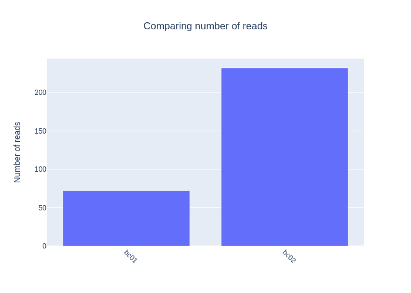

Figure 12.

**Figure 12. Number of reads kept after filtering**

**Table 7A. General summary of reads kept after filtering**

| General summary: | BC01 | BC02 |
| --- | --- | --- |
| Mean read length: | 725.0 | 725.0 |
| Mean read quality: | 12.5 | 12.7 |
| Median read length: | 725.0 | 725.0 |
| Median read quality: | 12.6 | 12.6 |
| Number of reads: | 72.0 | 232.0 |
| Read length N50: | 725.0 | 725.0 |
| STDEV read length: | 0.0 | 0.0 |
| Total bases: | 55,224.0 | 177,944.0 |

**Table 7B. Number, percentage and megabases of reads above quality cutoffs**

| Quality | BC01 |  | BC02 |  |
| --- | --- | --- | --- | --- |
| >Q5: | 72 (100.0%) | 0.1Mb | 232 (100.0%) | 0.2Mb |
| >Q7: | 72 (100.0%) | 0.1Mb | 232 (100.0%) | 0.2Mb |
| >Q10: | 65 (90.3%) | 0.0Mb | 208 (89.7%) | 0.2Mb |
| >Q12: | 41 (56.9%) | 0.0Mb | 141 (60.8%) | 0.1Mb |
| >Q15: | 5 (6.9%) | 0.0Mb | 34 (14.7%) | 0.0Mb |

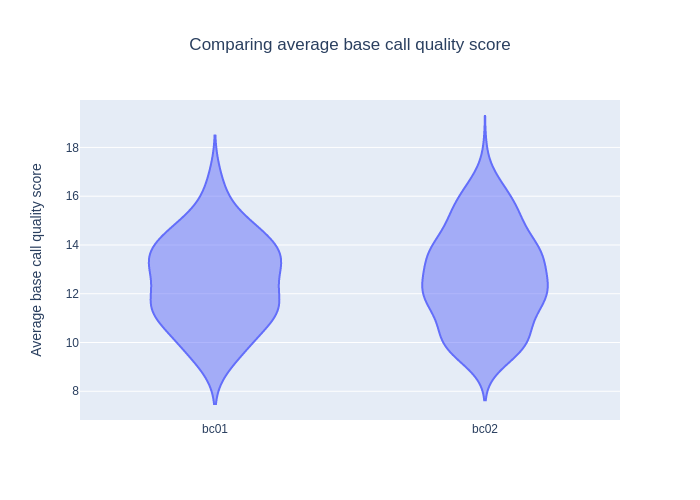

**Figure 13. Violin Plot of Mean Base Quality**

### Mapping to FBM05 reference

This was done above (the first time around), but was re-done using the new filtered sequences (72 BC01 reads & 232 BC02 reads). One BC02 sequence was not mapped.

**Table 8. Summary of reads mapped to FBM05 reference**

| Barcode | No.of reads | Mean read quality | Read N50 | Error rate | Mismatches | Bases mapped |
| --- | --- | --- | --- | --- | --- | --- |
| BC01 | 72 | 12.5 | 725 | 8.263081e-02 | 3754 | 55224 |
| BC02 | 231 | 12.7 | 725 | 8.704104e-02 | 12716 | 177177 |

### Mapping to LcDv70 reference

**Table 9. Summary of reads mapped to LcDv70 reference**

| Barcode | No.of reads | Mean read quality | Read N50 | Error rate | Mismatches | Bases mapped |
| --- | --- | --- | --- | --- | --- | --- |
| BC01 | 72 | 12.5 | 725 | 8.526254e-02 | 3915 | 55224 |
| BC02 | 231 | 12.7 | 725 | 8.171151e-02 | 12054 | 177177 |

### Mapping to Both references

**Note:** Both reference Sanger sequences are in a single FASTA file (`FBM05_LcDv70_Dv1F3.fas`).

```
minimap2 -ax map-ont -t 12  ../FBM05_LcDv70_Dv1F3.fas F3_full_length_trimmed_bc01.fastq --sam-hit-only > F3_bothmap_full_length_trimmed_bc01.sam

minimap2 -ax map-ont -t 12  ../FBM05_LcDv70_Dv1F3.fas F3_full_length_trimmed_bc02.fastq --sam-hit-only > F3_bothmap_full_length_trimmed_bc02.sam
```

**Table 10. Summary of reads mapped to both references**

| Barcode | No.of reads | Mean read quality | Read N50 | Error rate | Mismatches | Bases mapped |
| --- | --- | --- | --- | --- | --- | --- |
| BC01 | 72 | 12.5 | 725 | 8.355263e-02 | 3810 | 55224 |
| BC02 | 231 | 12.7 | 725 | 8.168938e-02 | 12050 | 177177 |

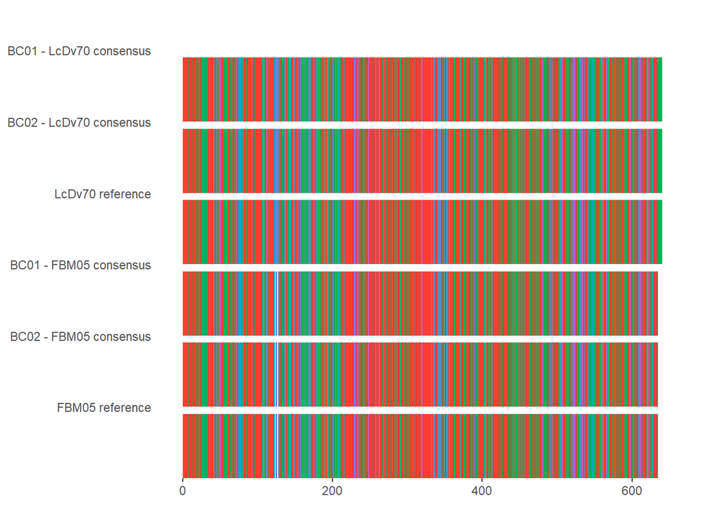

**Figure 14. Alignment of consensus sequences generated when mapping to each reference**

## Confusion matrix!

The number of sequences mapped to each reference was checked in Tablet.

**BC01:** - 56/72 mapped to FBM05 (correct) - 16/72 mapped to LcDv70 (wrong)

```r
library(caret)
lvs <- c("FBM05", "LcDv70")

truth <- factor(rep(lvs, times = c(72, 231)),
                levels = rev(lvs))


pred <- factor(
  c(
    rep(lvs, times = c(56, 16)),
    rep(lvs, times = c(2, 229))),
  levels = rev(lvs))


caret::confusionMatrix(pred, truth)
```

```
## Confusion Matrix and Statistics
##
##           Reference
## Prediction LcDv70 FBM05
##     LcDv70    229    16
##     FBM05       2    56
##
##                Accuracy : 0.9406
##                  95% CI : (0.9077, 0.9644)
##     No Information Rate : 0.7624
##     P-Value [Acc > NIR] : < 2.2e-16
##
##                   Kappa : 0.8243
##
##  Mcnemar's Test P-Value : 0.002183
##
##             Sensitivity : 0.9913
##             Specificity : 0.7778
##          Pos Pred Value : 0.9347
##          Neg Pred Value : 0.9655
##              Prevalence : 0.7624
##          Detection Rate : 0.7558
##    Detection Prevalence : 0.8086
##       Balanced Accuracy : 0.8846
##
##        'Positive' Class : LcDv70
##
```

**Accuracy is calculated as the number of correctly assigned reads(56 + 229) divided by the total (303)**

**Sensitivity is calculated as the proportion of BC02 reads were correctly assigned to LcDv70 (229/231), and specificity is calculated as the proportion of BC01 reads correctly assigned to FBM05 (56/72).**

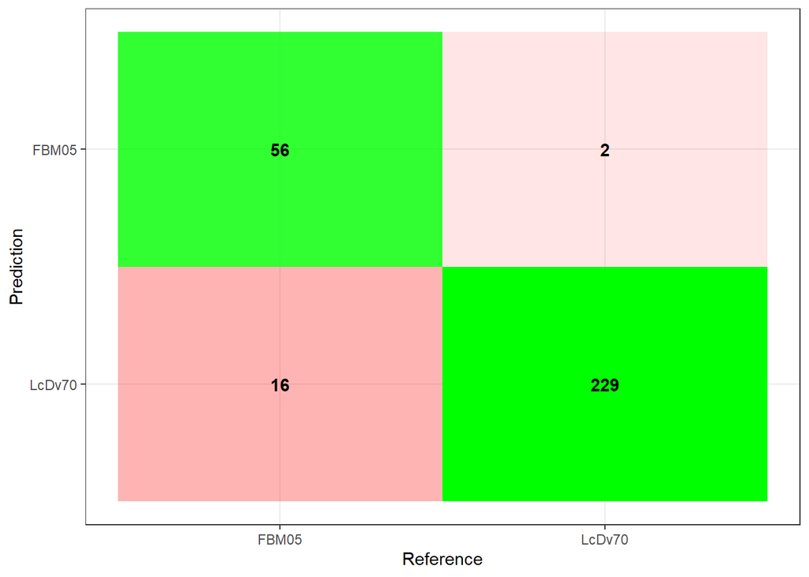

**Figure 15. Confusion Matrix: Green cells = Correctly matched reads to reference, red cells = incorrectly matched.**

## Extra note on quality scores

I found a [blog post](https://gigabaseorgigabyte.wordpress.com/2018/08/30/update-on-oxford-nanopore-basecall-quality-scores/) that better illustrates the relationship between q-score and percent identity by [wdecoster](https://gigabaseorgigabyte.wordpress.com/author/wouterdecoster/):

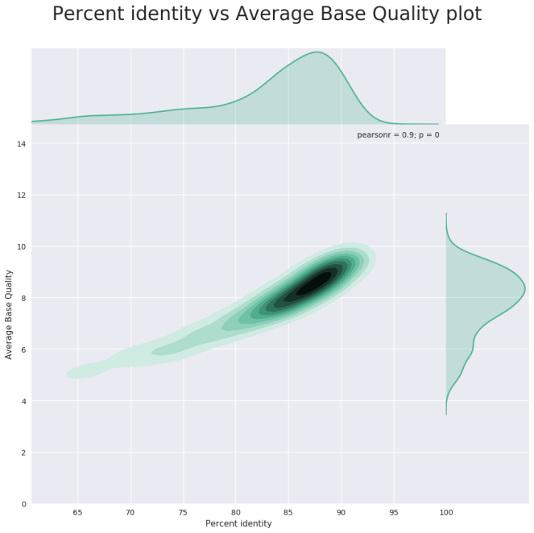

**Figure A. Q-scores**

**Figure A. Percent Identity vs Average Base Quality Taken from blog post by `wdecoster` written 2018.**

So a q-score of 9 is somewhere between 85-90% accuracy.

## Versions

Run on:

- Bio-Linux 8.0.7
- Linux 3.13.0-170-generic

Environment:

- conda 4.8.3

Pkgs:

- R version 3.6.1 (2019-07-05) – “Action of the Toes”
- NanoPlot 1.35.1
- NanoStat 1.1.2
- NanoFilt 2.8.0
- MinIONQC version 1.4.1
- minimap2 2.17-r941
- bcftools 1.9
- samtools 1.7
- Python 3.6.13
- seqkit v0.15.0

Guppy:

- Windows 10
- Guppy v 4.4.2